# Data Dive - Time_based_Data

Amritha Prakash

2023-11-10

### **Load the libraries**

[output not shown]

### **Load the Superstore Data**

```r
Superstore_data=read.csv("SampleSuperstore_final.csv")
head(Superstore_data)
```

```
##        Ship.Mode   Segment       Country            City      State Postal.Code
## 1   Second Class  Consumer United States       Henderson   Kentucky       42420
## 2   Second Class  Consumer United States       Henderson   Kentucky       42420
## 3   Second Class Corporate United States     Los Angeles California       90036
## 4 Standard Class  Consumer United States Fort Lauderdale    Florida       33311
## 5 Standard Class  Consumer United States Fort Lauderdale    Florida       33311
## 6 Standard Class  Consumer United States     Los Angeles California       90032
##   Region        Category Sub.Category    Sales Quantity Discount    Profit
## 1  South       Furniture    Bookcases 261.9600        2     0.00   41.9136
## 2  South       Furniture       Chairs 731.9400        3     0.00  219.5820
## 3   West Office Supplies       Labels  14.6200        2     0.00    6.8714
## 4  South       Furniture       Tables 957.5775        5     0.45 -383.0310
## 5  South Office Supplies      Storage  22.3680        2     0.20    2.5164
## 6   West       Furniture  Furnishings  48.8600        7     0.00   14.1694
```

```r
library(wikipediatrend)
```

### Retrieving Data for Time Series Analysis

- Since I do not have a data set with time values within it, I am picking wikipedia page views dataset in order to work on Time Series Analysis .
- I am planning to take up Exercise topic , to analyse how far people were concious about exercising back in the time line from 2007-12-10 to 2015-12-31.
- Following code contains is extracting data for same.

```r
exercise_pageviews <- wpd_get_exact(page="Exercise", from="2006-12-01", to="2015-12-31", lang="en", warn=TRUE)
```

```r
tail(exercise_pageviews)
```

```
##     language  article       date views
## 726       en exercise 2015-12-26     0
## 727       en exercise 2015-12-27     0
## 728       en exercise 2015-12-28     0
## 729       en exercise 2015-12-29     0
## 730       en exercise 2015-12-30     0
## 731       en exercise 2015-12-31     0
```

- Since the data is extracted from wikipedia, the date when the Exercise page was viewed is already in Date format “%y-%m-%d”.Hence, I believe we dont need to select a column that encodes time (e.g., “date”, “timestamp”, “year”, etc.)and Convert into a Date in R.
- In order to further choose a column of data to analyze over time, considering it to be “response-like”. We can take it as view. Hence **Response-like variable = VIEW**

# Create Tsibble

- Further creating a tsibble object to pick the date and response variable, here view in our case. This can be used to plot the data over time.

```r
ex_pgViews <- select(exercise_pageviews, date, views)
ex_pgViewsTS <- as_tsibble(ex_pgViews, index = date)
head(ex_pgViewsTS)
```

```
## # A tsibble: 6 x 2 [1D]
##   date       views
##   <date>     <int>
## 1 2007-12-10  1725
## 2 2007-12-11  1546
## 3 2007-12-12  1548
## 4 2007-12-13  1568
## 5 2007-12-14  1248
## 6 2007-12-15   803
```

### Plotting -

- Full Plotting -

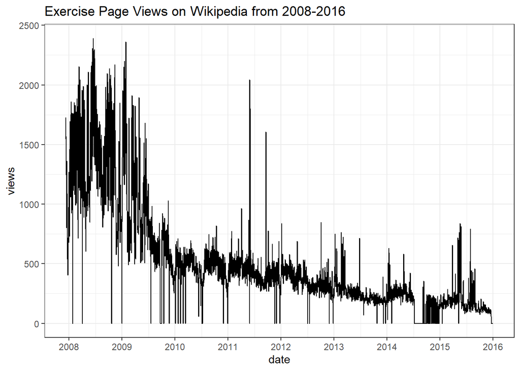

```r
ex_pgViewsTS %>%
  ggplot() +
  geom_line(mapping = aes(x = date, y = views)) +
  labs(title = "Exercise Page Views on Wikipedia from 2008-2016") +
  theme_bw() +
  scale_x_date(breaks = "1 year", labels = \(x) year(x))
```

- Here from the above plot can see drastic reduction of pageview/search for “exercise” over time within the range 2008 - 2016 . But overall the search about exercise is reducing. These dips maybe associated with the increase in how various technological advances happened over the years and maybe people have not been that health conscious.
- Following is the plot when tech was just evolving i.e. between 2008 - 2011.

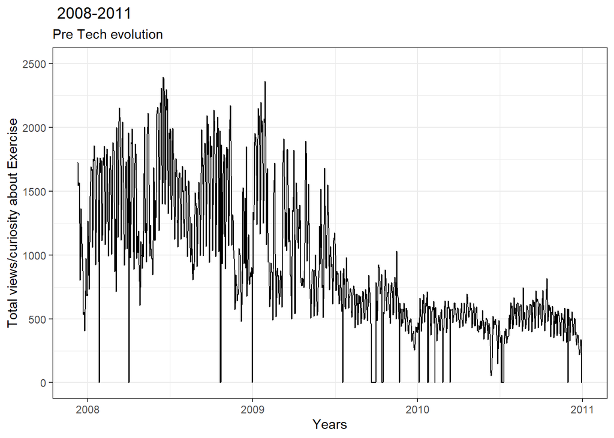

```r
  ex_pgViewsTS %>%
  filter(date < as.Date('2011/01/01')) |>
  ggplot() +
  geom_line(mapping = aes(x = date, y = views)) +
  ylim(0,2500) +
  labs(title = ' 2008-2011',
       subtitle = 'Pre Tech evolution',
       x = 'Years',
       y = 'Total views/curiosity about Exercise') +
  theme_bw() +
  scale_x_date(breaks = "1 year", labels = \(x) year(x))
```

This graph plots the window of time before Technology overtook and exercise was important and people took time to understand it better.

- Following is the plot when tech evolved better i.e. between 2011 - 2016.

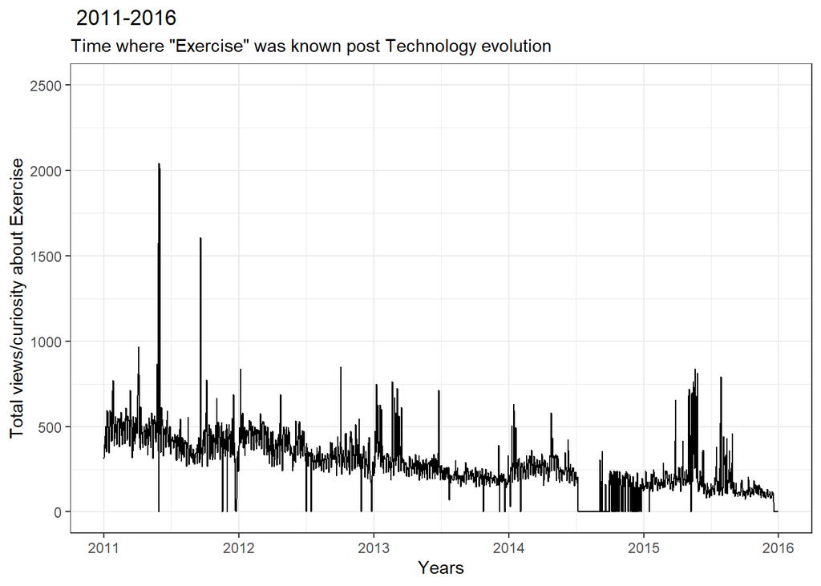

```r
  ex_pgViewsTS %>%
  filter(date >= as.Date('2011/01/01')) |>
  ggplot() +
  geom_line(mapping = aes(x = date, y = views)) +
  ylim(0,2500) +
  labs(title = ' 2011-2016',
       subtitle = 'Time where "Exercise" was known post Technology evolution',
       x = 'Years',
       y = 'Total views/curiosity about Exercise') +
  theme_bw() +
  scale_x_date(breaks = "1 year", labels = \(x) year(x))
```

This graph plots the window of time post Technology overtook and exercise was already known to most people and hence maybe they stoped searching for it.